fossil

# LIMPIC, dug back up.

Its code runs again. Figs 2 to 7 came back the same, and so did Fig. 8’s peaks.

[Read the code notes](https://github.com/jeonglab-bcm/fossil/tree/main/PMC1847688/figure-reproduction#what-the-code-does-against-the-paper)

## Fig. 2

Raw MALDI-TOF mass spectrum from a human plasma sample, with background noise and baseline drift.

AgreesRerun of the authors’ code

Published

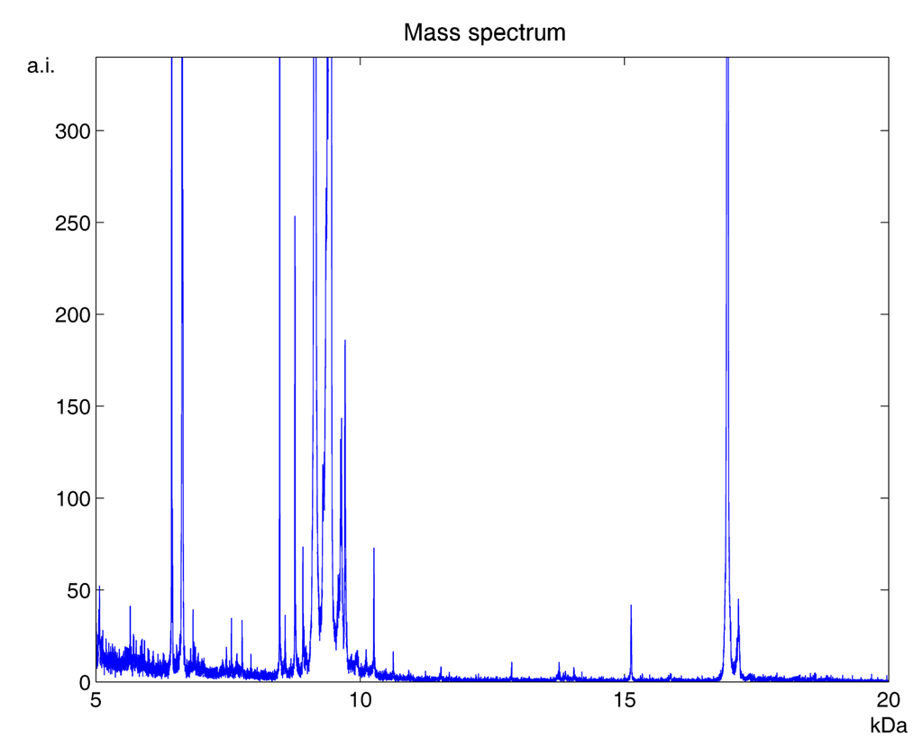

Our run

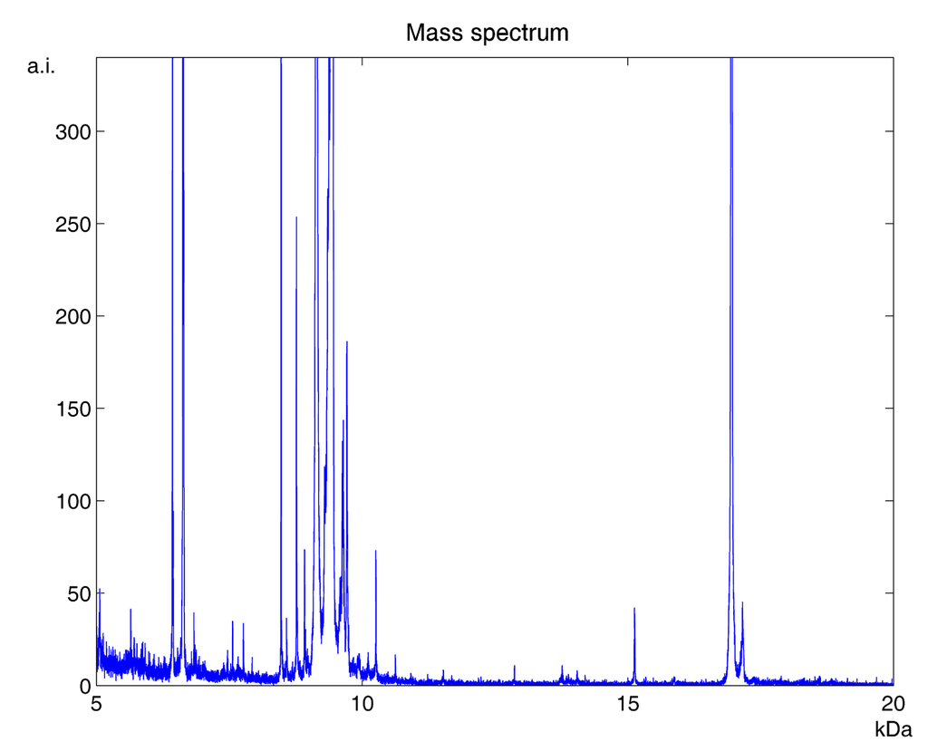

**Pixel size**

3056 × 2475

**≤2 px both ways**

99.99% and 99.96%

**Mean |Δ| grey**

0.8

Plasma file P_15 is the example spectrum. The figure plots its raw counts divided by 5.

## Fig. 3

Difference between the spectrum before and after the Kaiser filter, window length 10, 20, 30 and 40 (a to d).

AgreesRerun of the authors’ code

Published

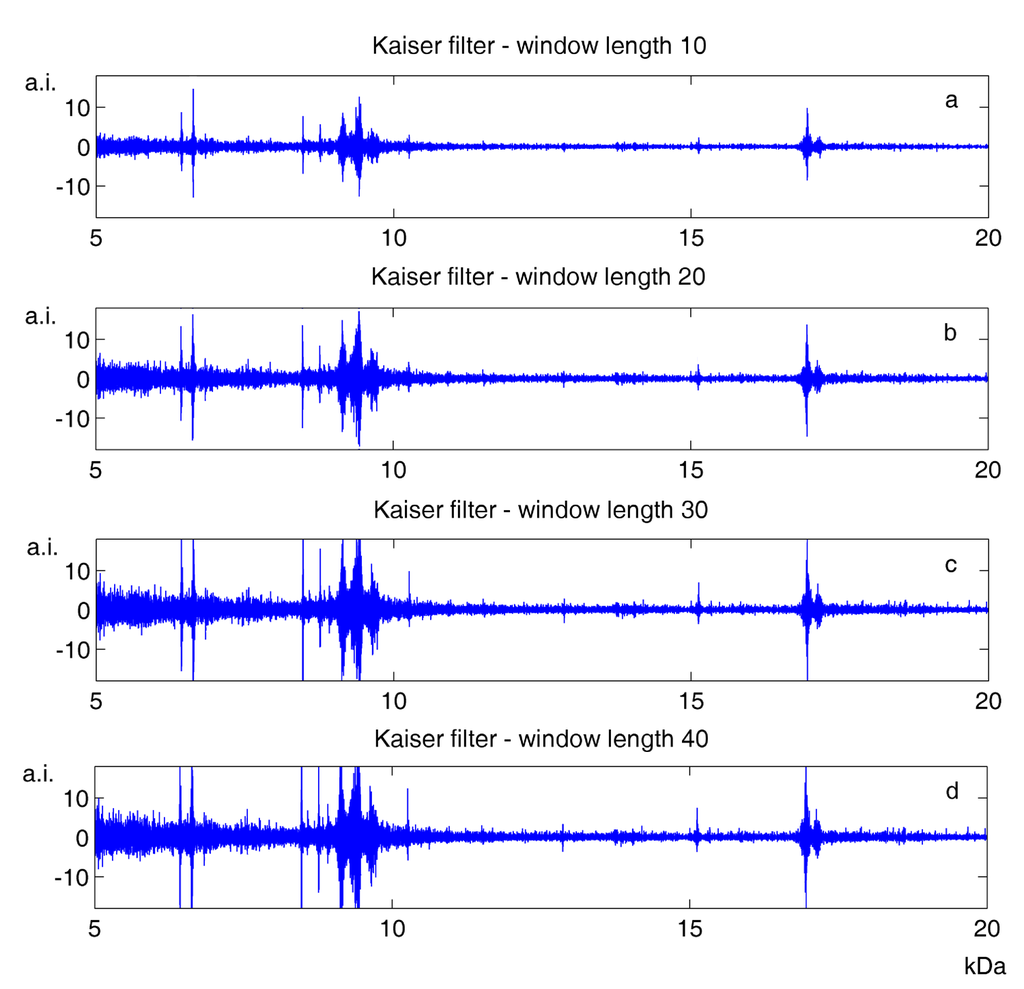

Our run

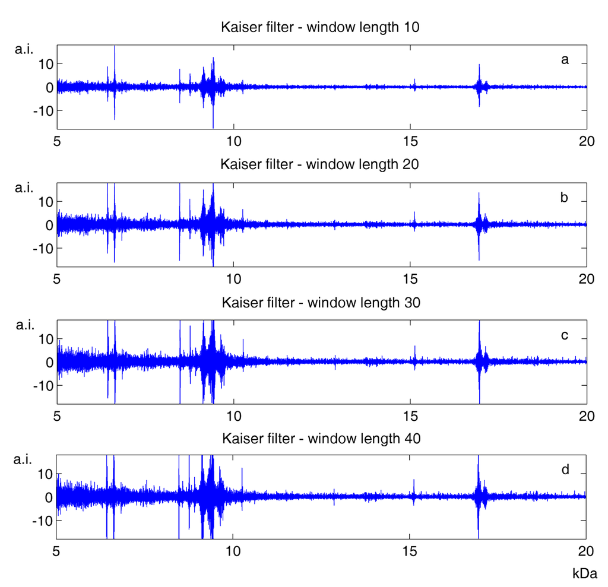

**Pixel size**

3012 × 2908

**panel a, ≤2 px both ways**

99.99% and 99.42%

**panel b, ≤2 px both ways**

99.99% and 99.13%

**panel c, ≤2 px both ways**

99.99% and 99.98%

**panel d, ≤2 px both ways**

99.99% and 99.98%

**Mean |Δ| grey**

1.12

LIMPIC’s smoothing is a Savitzky-Golay filter run forward and backward, despite the “Kaiser” label. Raw minus smoothed, divided by 5.

## Fig. 4

Difference before and after smoothing. Only panel c, the Kaiser filter, is LIMPIC’s.

AgreesRerun of the authors’ code

Published

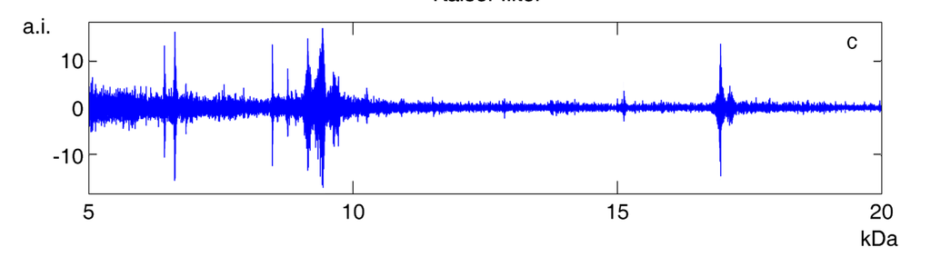

Our run

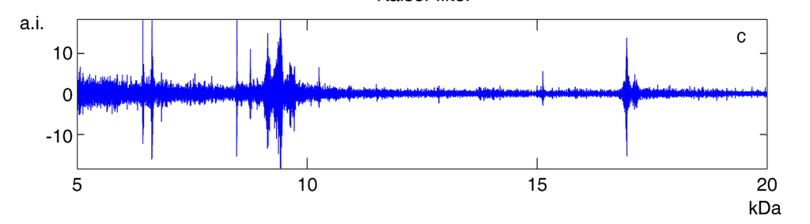

**Pixel size**

3082 × 850

**panel c, ≤2 px both ways**

99.97% and 98.99%

**Mean |Δ| grey**

1.35

Same signal as Fig. 3b. The Savitzky-Golay and wavelet panels (a, b) are not LIMPIC’s and are not drawn.

## Fig. 5

Baseline drift by the minimum-value interpolation method (blue) and LIMPIC’s peak-elimination method (red).

AgreesRerun of the authors’ code

Published

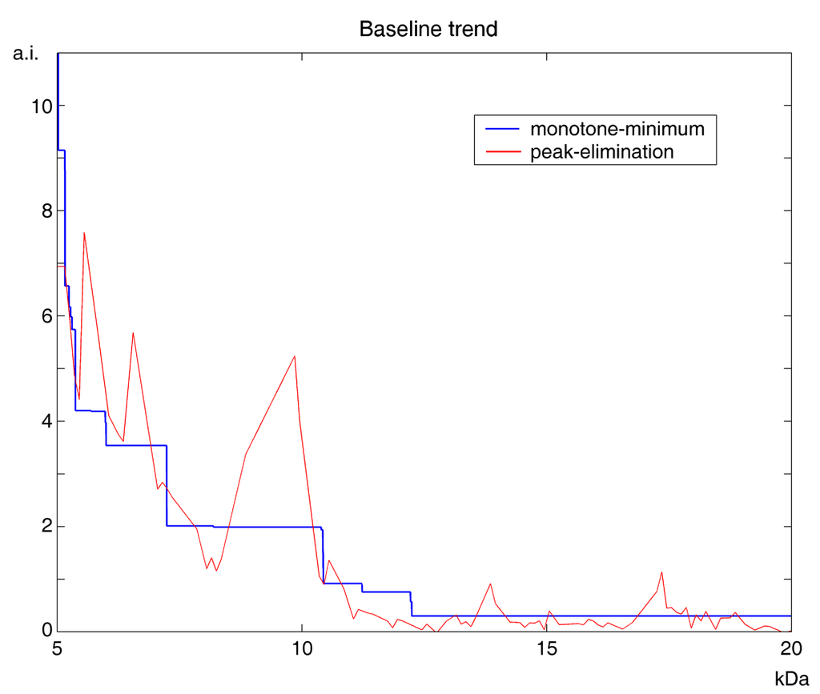

Our run

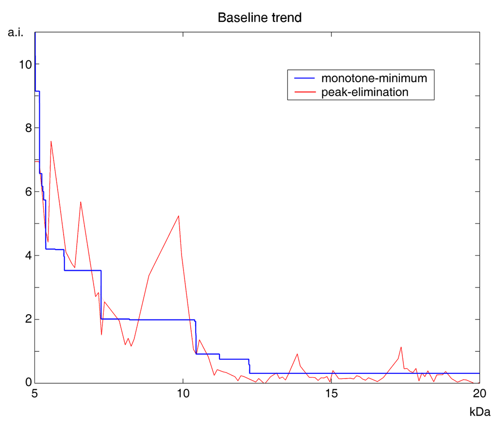

**Pixel size**

2994 × 2535

**Peak elimination (red), ≤2 px both ways**

99.38% and 94.69%

**Minimum value (blue), ≤2 px both ways**

99.99% and 98.45%

**Mean |Δ| grey**

0.42

Red is LIMPIC’s baseline, through the minima of the 100 Da blocks without peaks. The paper gives no settings for the blue minimum-value baseline; a wavelet-denoised running minimum, CROMWELL’s approach, matches it with one combination found by search. Ours dips to 1.5 near 7.25 kDa where the published red does not.

## Fig. 6

The spectrum at 5 to 8 and 14.75 to 17.75 kDa (a, b) and the noise LIMPIC removes there (c, d).

AgreesRerun of the authors’ code

Published

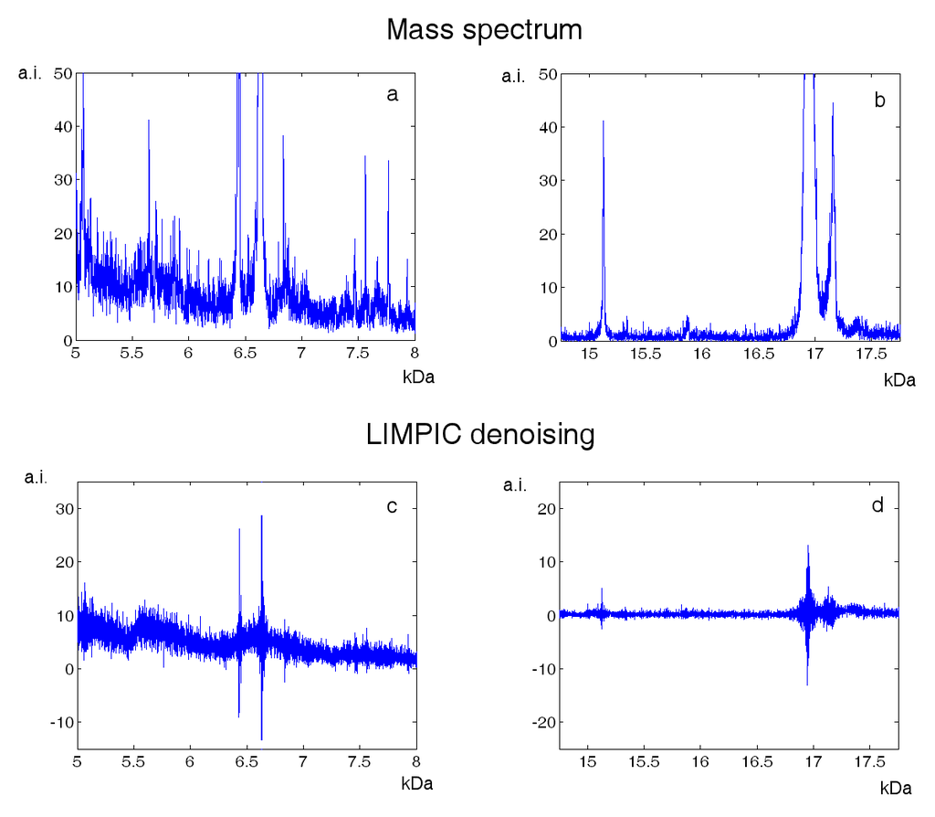

Our run

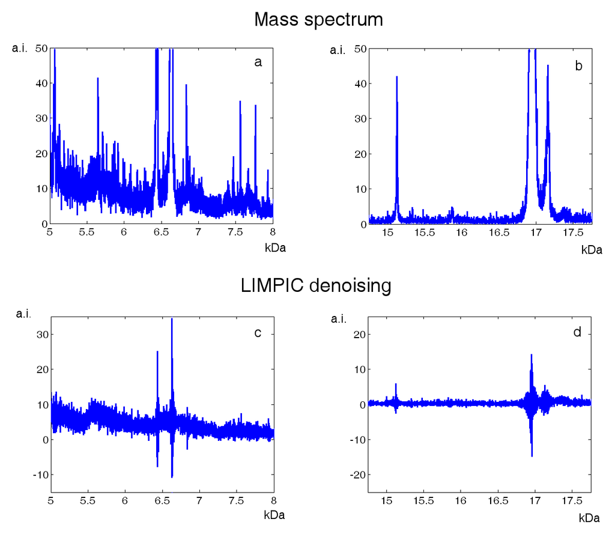

**Pixel size**

1197 × 1045

**panel a, ≤2 px both ways**

100% and 98.51%

**panel b, ≤2 px both ways**

100% and 99.13%

**panel c, ≤2 px both ways**

97.93% and 96.94%

**panel d, ≤2 px both ways**

100% and 97.63%

**Mean |Δ| grey**

4.62

Panels a and b are the raw spectrum; c and d are what LIMPIC removes (smoothing residual plus baseline), divided by 5. The APEX, CENTROID and CROMWELL panels (e to h) are not drawn.

## Fig. 7

Peaks detected in 8.73 to 9.02 kDa, marked by red crosses. Only the top panel, LIMPIC, is shown.

AgreesRerun of the authors’ code

Published

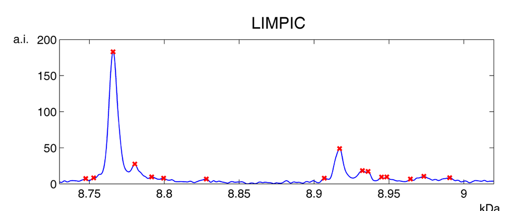

Our run

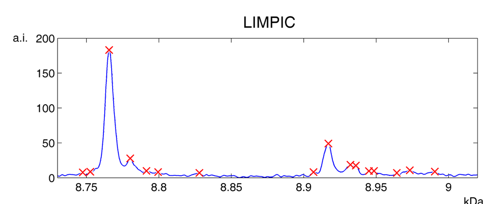

**Pixel size**

3052 × 1250

**LIMPIC, ≤2 px both ways**

99.57% and 99.93%

**Peaks**

16 of 16 at our positions

**Published peaks without ours**

0

**Mean |Δ| grey**

0.82

The processed spectrum and LIMPIC’s peaks, 8.73 to 9.02 kDa. The APEX, CENTROID and CROMWELL panels below it are not drawn.

## Fig. 8

The same peaks classified across the 30 spectra: green for a detection rate of 0.5 or more, red for the rest.

Partly agreesRerun of the authors’ code

Published

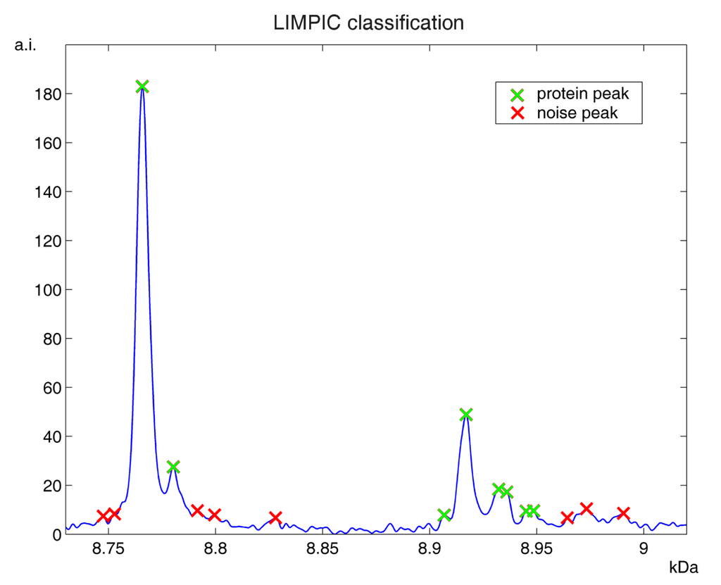

Our run

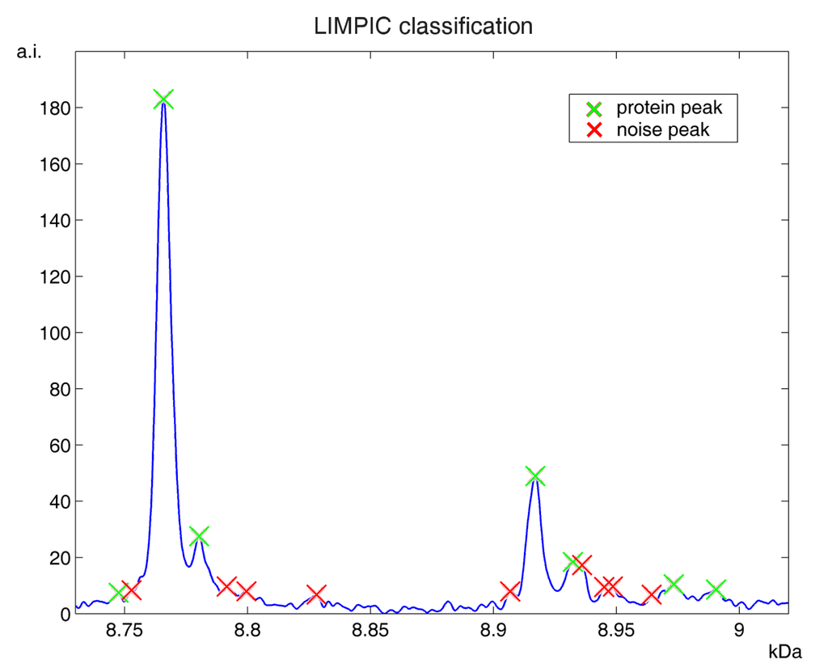

**Pixel size**

3012 × 2445

**≤2 px both ways**

100% and 99.96%

**Peaks**

16 of 16 at our positions

**Published peaks without ours**

0

**Same colour as ours**

9 of 16

**Mean |Δ| grey**

0.55

Every published cross sits on one of our 16 peaks. Our 30-spectrum classification colours 9 of them as the paper does; 7 differ. The paper’s classes came from a run we could not repeat (see Additional File 4, below).

## Fig. 9

PDR of every peak class across the 30 plasma spectra (a) and its histogram (b).

Partly agreesDrawn from Additional File 4

Published

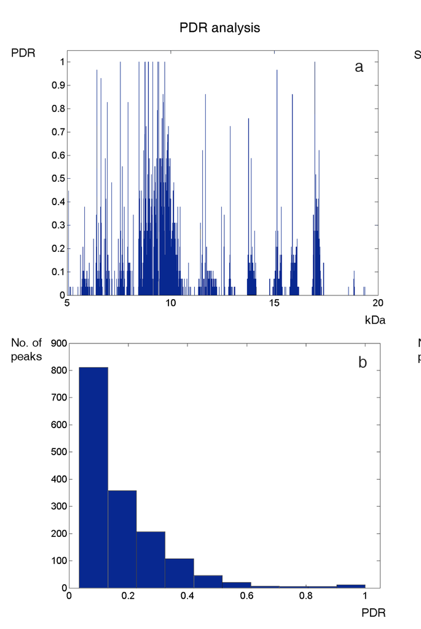

Our run

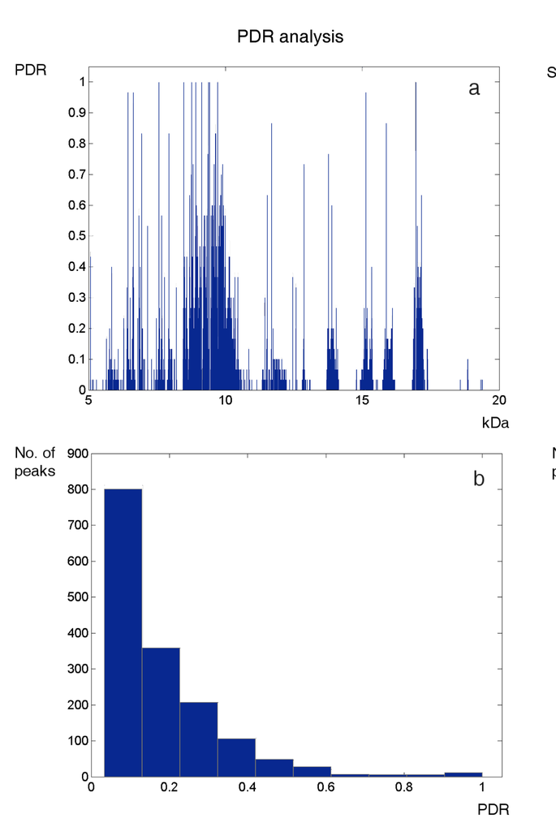

**Pixel size**

3000 × 4484

**Panel a, ≤2 px both ways**

98.63% and 99.46%

**Panel b, largest bar gap**

10.4 peaks

**Peak classes**

1,581

**Mean |Δ| grey**

1.88

Drawn from Additional File 4, the authors’ own list of 1,581 plasma peak classes, not from our run. Histogram counts [801, 359, 207, 106, 49, 28, 7, 6, 6, 12]; published bars read as [811, 359, 208, 108, 47, 21, 7, 6, 6, 12]. Panels c and d are left out: their SNR divides by a smooth noise curve that LIMPIC 1.1 does not compute.

## Tables 1 to 3

LIMPIC’s rows: cytochrome C intensity across 5 replicates (Table 1), classes detected per concentration (Table 2), and peaks, classes and hit rate (Table 3).

DiffersRerun of the authors’ code

| In vitro | Paper mean | Ours mean | Paper CV | Ours CV | Replicates with the peak | Paper classes | Ours classes |
| --- | --- | --- | --- | --- | --- | --- | --- |
| 2.5 fmol | 1.17 | 1.55 | 0.09 |  | 1 of 5 | 8 | 499 |
| 5 fmol | 4.65 | 5.78 | 0.08 | 0.11 | 3 of 5 | 7 | 669 |
| 7.5 fmol | 5.32 | 5.99 | 0.12 | 0.35 | 3 of 5 | 10 | 705 |
| 10 fmol | 17.07 | 25.63 | 0.16 | 0.53 | 5 of 5 | 8 | 717 |
| 25 fmol | 94.03 | 181.01 | 0.15 | 0.82 | 5 of 5 | 10 | 696 |
| 50 fmol | 277.37 | 404.71 | 0.15 | 0.69 | 5 of 5 | 11 | 619 |

| Table 3 | Paper | Ours |
| --- | --- | --- |
| In vitro peaks per spectrum | 16 | 666.7 |
| In vitro hit rate | 0.69 | 0.98 |
| Plasma peaks per spectrum | 146 | 302.4 |
| Plasma classes selected | 62 | 104 |
| Plasma hit rate | 0.42 | 0.34 |

With the settings it ships with, LIMPIC 1.1 finds about 667 peaks in each in vitro spectrum, where the paper reports 16. The paper does not give the settings it used for Tables 1 to 3, so these rows do not come back. Table 1’s cytochrome C class is the one within 300 ppm of 12,360.5; where only one replicate has it, there is no CV.

## What came back

**LIMPIC in Python**

Each MATLAB file of Additional File 1 ported function by function. Against the authors’ code run in GNU Octave, every intermediate signal, all 9,071 plasma peaks and every peak class agree to six decimals.

**The code runs again**

As published, find_intervals.m keeps blocks with MATLAB’s kurtosis below 1. That kurtosis is 3 for Gaussian noise and never below 1, so no block passes and the code stops. With excess kurtosis (0 for Gaussian noise) Figs 7 and 8 come back peak for peak, so that is what the authors ran.

**The example spectrum**

Figs 2 to 8 show plasma file P_15, as raw counts divided by 5.

**Fig. 5’s comparison baseline**

A wavelet-denoised running minimum up to 20 kDa (db4, 9 levels, hard threshold at 6 MAD). The paper gives no settings; this one combination was found by search.

**A damaged input file**

Line 32,768 of SOL_5_TXT/SOL_calib_08e.txt in Additional File 2 is corrupt in the publisher’s archive. It is skipped.

## What stayed buried

- The run behind Additional File 4. It lists 7,893 peaks in 1,581 classes; LIMPIC 1.1 on the 30 plasma files gives 9,071 peaks in 2,077 classes, and at most 17% of our peak intensities equal one of its values
- The smooth noise model behind Figs 9c and 9d
- The settings behind Tables 1 to 3
- APEX, CENTROID and CROMWELL’s settings, for the other panels of Figs 4, 6 and 7

## What we matched

The figures are MATLAB plots, and the authors’ original 600 dpi files survive. We kept each published axes box, erased its traces, and drew ours in their place from our own run. The pixel to data map of each panel comes from its box and tick marks alone; nothing inside the box is fitted.

**Our run**

LIMPIC 1.1, the paper’s Additional File 1, ported to Python function by function, on the paper’s own spectra (Additional Files 2 and 3). The port gives the same peaks, classes and signals as the MATLAB code run in GNU Octave, to six decimals.

**Example spectrum**

Figs 2 to 8 show plasma file P_15, plotted as raw counts divided by 5.

**Axes**

One linear map per axis, from the tick marks on the box edges and the values printed beside them. The tick fit is within a tenth of a pixel or so in every panel.

**Lines and markers**

Our traces are drawn in the published colour and line width (3 px, 5 px in Fig. 7, 6 px in Fig. 8). Peaks in Figs 7 and 8 are crosses at our peak positions.

**Scores**

“Paper ink ≤2 px from ours” is the share of published trace pixels within 2 px of a trace pixel of ours; the other score is the reverse. Legends are left out of both.

**Reading the views**

Overlay: ink is the paper only, light green is the reproduction only, dark green is both. Difference: darker means a larger grey-level difference (×2). Where ours matches, the published trace is redrawn on the same pixels, so most of the figure shows as both.

## The session

Session not recorded: no log of the agent session was kept for this reproduction.